# Genomic Features between Two Range Sets

The value of a particular genomic feature is pre-calcuated for each base site in the human genome, by examining the 100-bp enclosing window centered upon the site in question. For an interval of continuous genomic sites (termed “a range” in Bioconductor), the site-wise values are averaged to the interval level feature value. The interval-level feature values are compared between two input sets with statistical tests, so that the user will be informed as to which feature(s) demonstrate possible statistically significant difference between the two input interval sets.

## Catalogue of input intervals by genomic region type

The genomic region type of each input interval are identified as Intron, Exon, or Intergene (intergenic region), on account of the nature of the embedding DNA fragment. An interval can be tagged with multiple region type labels, because different region type instances may overlay and also partial overlap is counted in type identification.

|  | introns(%) | exons(%) | intergene(%) | totalNum |
| --- | --- | --- | --- | --- |
| H3K27ac | 22.3 | 53.6 | 24.6 | 996 |
| H3K27me3 | 39.5 | 39.5 | 30.2 | 43 |

## Statistical comparison of genomic features

For all features except homology (HS), two-sample Wilcoxon test and Kolmogorov-Smirnov test are performed to compare the mean feature scores of intervals between two input sets. For homology, Zero-Inflated Poisson (ZIP) regression and Negative Binomial (NB) regression is employed to examine the difference of (median) redundancy counts of intervals between two input sets.

Med1 & Med2: median values of interval set one and interval set two.

W, W+, W-: test statistics in Wilcoxon test (for all features except HS). W, two-tailed test; W+, one-tailed, alternative hypothesis is “set two greater than set one;” W-, one-tailed, alternative “set two less than set one.”

W.p, W+.p, W-.p: p-values out of Wilcoxon test.

D, D+, D-: test statistic in Kolmogorov-Smirnov test (for all features except HS). As with Wilcoxon test, “+” and “-” denote one-tailed alternative hypotheses, for “greater” and “less”, respectively.

D.p, D+.p, D-.p: p-values out of Kolmogorov-Smirnov test.

*For HS, specially, W and W.p denote coefficient and p out of ZIP regression, and D and D.p denote those from NB regression.

|  | Med1 | Med2 | W* | W.p* | W+ | W+.p | W- | W-.p | D* | D.p* | D+ | D+.p | D- | D-.p |
| --- | --- | --- | --- | --- | --- | --- | --- | --- | --- | --- | --- | --- | --- | --- |
| delta_G37 | -158.592 | -158.083 | 19768.0 | 0.393 | 19768.0 | 0.804 | 19768.0 | 0.197 | 0.192 | 0.095 | 0.192 | 0.047 | 0.098 | 0.454 |
| delta_H | -838.502 | -835.658 | 17583.0 | 0.047 | 17583.0 | 0.977 | 17583.0 | 0.023 | 0.227 | 0.029 | 0.227 | 0.014 | 0.044 | 0.851 |
| Entropy2 | 2.496 | 2.484 | 22094.5 | 0.724 | 22094.5 | 0.362 | 22094.5 | 0.638 | 0.131 | 0.481 | 0.112 | 0.356 | 0.131 | 0.244 |
| Entropy3 | 3.499 | 3.469 | 22332.5 | 0.634 | 22332.5 | 0.317 | 22332.5 | 0.683 | 0.133 | 0.459 | 0.125 | 0.274 | 0.133 | 0.233 |
| Entropy4 | 4.119 | 4.093 | 22515.0 | 0.568 | 22515.0 | 0.284 | 22515.0 | 0.716 | 0.116 | 0.636 | 0.081 | 0.584 | 0.116 | 0.329 |
| GC | 68.644 | 67.557 | 23185.5 | 0.358 | 23185.5 | 0.179 | 23185.5 | 0.821 | 0.180 | 0.138 | 0.145 | 0.176 | 0.180 | 0.069 |
| HS | 1.000 | 1.000 | 21693.5 | 0.452 | 21693.5 | 0.226 | 21693.5 | 0.775 | 0.013 | 1.000 | 0.000 | 1.000 | 0.013 | 0.986 |

## Energy

Secondary structure is predicted for a 100-bp genomic window and folding energy is estimated based on thermodynamic parameters of DNA structure motifs. More information is available in SantaLucia and Hicks’ review paper (doi: 10.1146/annurev.biophys.32.110601.141800). Energy value is first calculated for each base site on account of the enclosing 100-bp window, and then averaged across each interval.

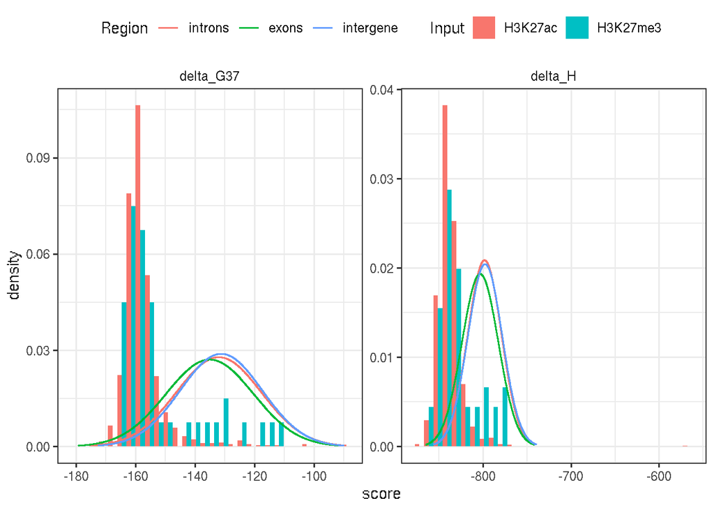

## Entropy

For a base site, Shannon entropy is employed to quantify the variability of n-mer oligonucleotides within a 100-bp enclosing window centered upon the site in question, and the base-wise entropy values are averaged to an interval-wise entropy. 2-mer, 3-mer, and 4-mer oligonucleotides are separately considered, thus giving rise to Entropy2, Entropy3, and Entropy4.

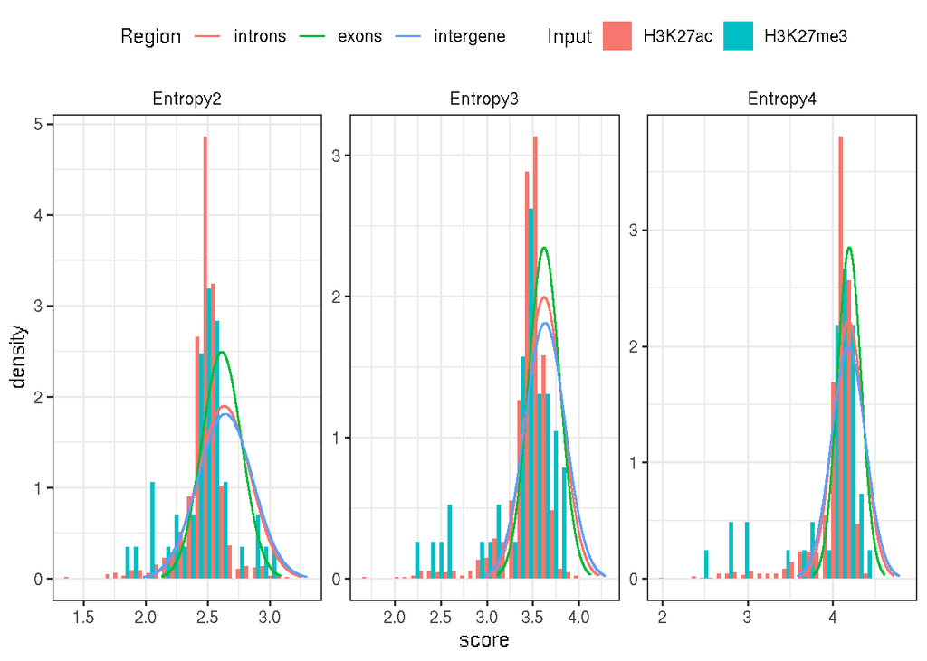

## GC content

For a base site, GC content is defined as the number of guanosines (G) and cytidines (C) in the 100-bp enclosing window centered upon the site in question. The GC content of an interval is the mean GC content across all bases in the interval.

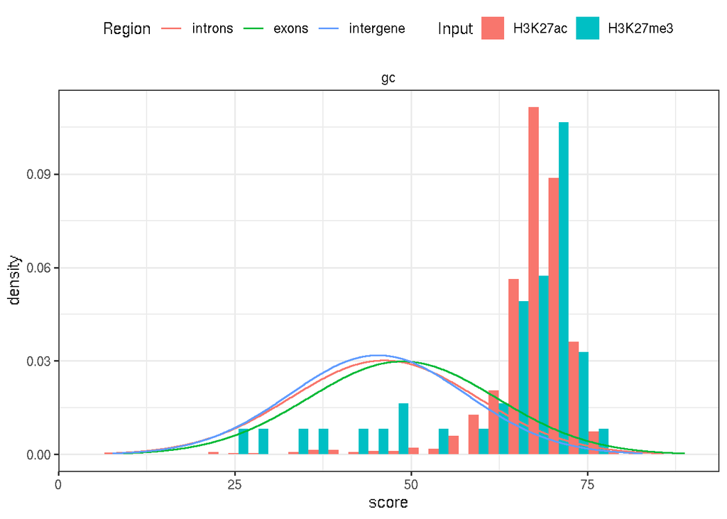

## Homology score (redundancy count)

For a base site, homology score is defined as the incidence of perfect or near-perfect (1 base mismatch) alignment to the whole genome of the 100-bp enclosing window centered upon the site in question. The homology score of an interval is the median mapping count across all bases in the interval.

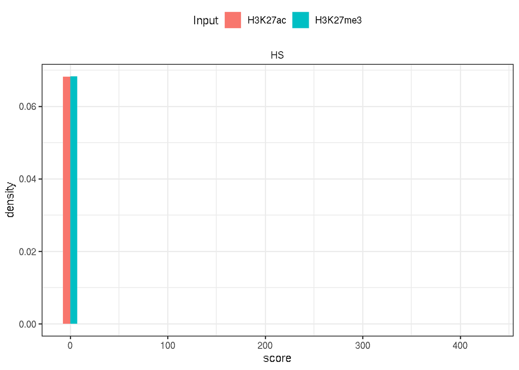